## Team Introduction

During our Master’s program as a part of Curriculum, We undertook “[Data Science with R](https://brain.cs.uni-magdeburg.de/kmd/DataSciR/)” Seminar during the summer semester 2021 under [M.Sc. Uli Niemann](https://www.kmd.ovgu.de/Team/Academic+Staff/Uli+Niemann.html) from the [Knowledge Management & Discovery Lab(KMD)](https://www.kmd.ovgu.de/) at the Farafin faculty in Otto-von-Guericke-University([OVGU](https://www.uni-magdeburg.de/)) Magdeburg. As per the scope of our Seminar , We opted for mandatory project based upon our preferences in Data Science. Our project “Classifying whether twitter author spreads hate using supervised learning” deals with formatting the text data, building explainable visualisations, extracting domain related features , performing different machine learning techniques and finally evaluating the results. We have created an introductory video(Please follow the below mentioned link) from which one can have a glimpse of our project and project details can be accessed through the navigation panels of the website. Team members behind this project are mentioned below.

[Project screencast](https://www.youtube.com/watch?v=_cLzOaIdFXE)

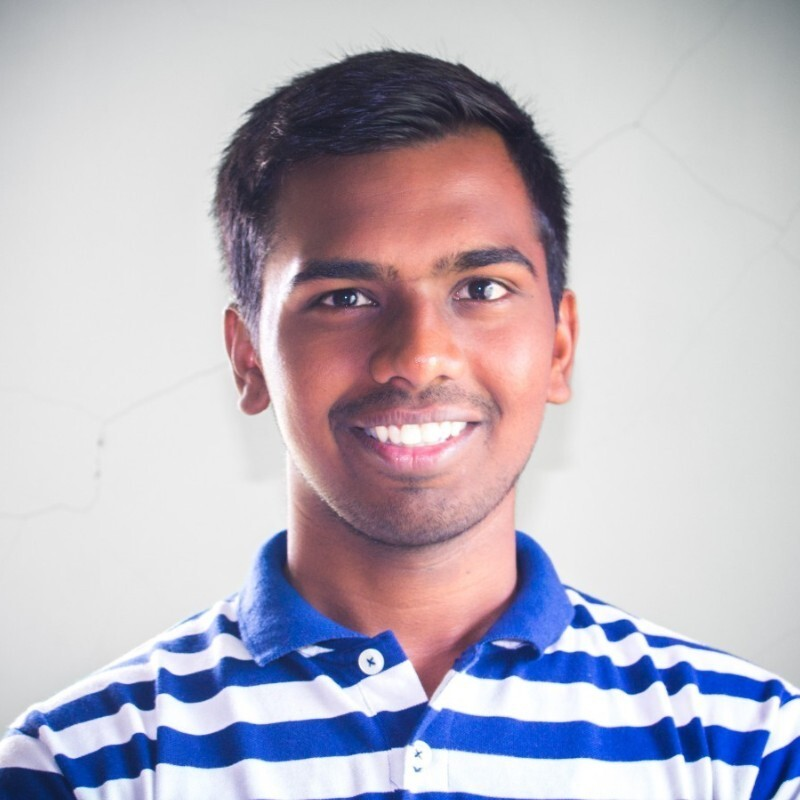

## Anish Singh

Student

Email

[figure not shown]

## Priyanka Singh

Student

Email

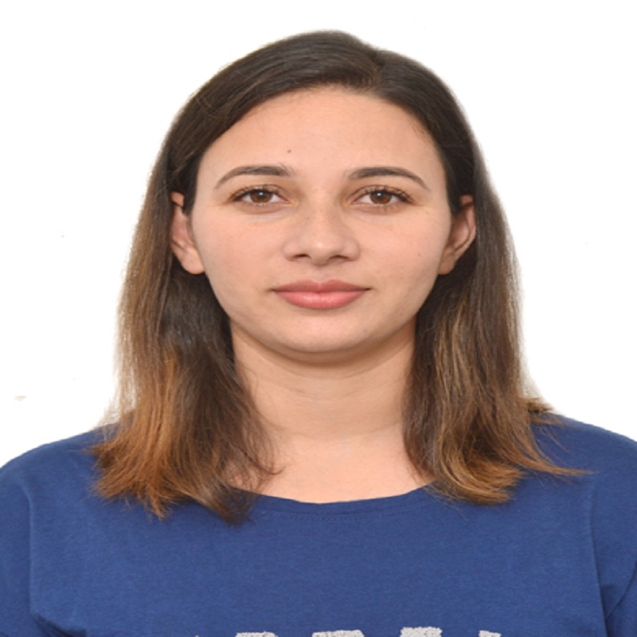

## Ramanpreet Kaur

Student

Email

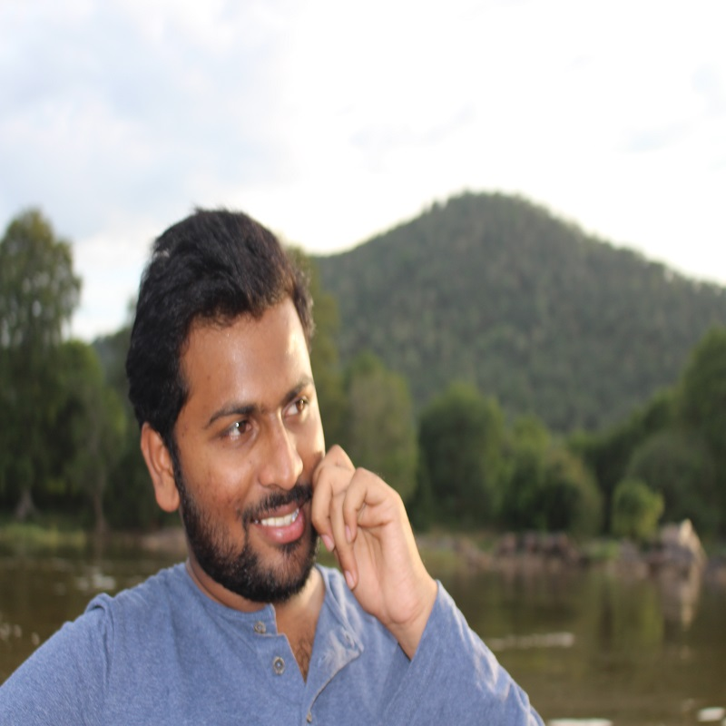

## Srinath Mannam

Student

Email

## 1) Background and motivation

Around the world, we are seeing an unsettling groundswell of racism, xenophobia, and intolerance – including rising anti-Semitism, anti-Muslim hatred, and persecution of Christians. Many forms of communication including Social media are being exploited as platforms for spreading hate, which unfortunately later leads to acts of discrimination and violence. Popular belief and prevailing sentiments among the public majority are being amplified for political gain which targets minorities, women, migrants, refugees and thus leading to human rights violations in any form. Hate speech is a danger to social stability, democratic values, peace.

The term hate speech is understood as any kind of communication in speech, writing or behavior, that attacks or uses pejorative or discriminatory language concerning a person or a group based on who they are, in other words, based on their religion, ethnicity, nationality, race, color, descent, gender or another identity factor. This is often rooted in, and generates intolerance and hatred and, in certain contexts, can be demeaning and divisive

Due to emergence of social media there has been increasing incidences of hate speech around the world on different subjects such as race, religion, gender,etc. Huge amount of data is generated on social media and it becomes important to detect the problem of hate speech to fight against misogyny and xenophobia. In the end we want to identify possible hate speech spreader on Twitter and restrict them, this can act as first step to stop hate speech from spreading in a community among online users and analyzing possible keywords that helpful in detecting hateful tweets.